# Class 8: Unsupervised Machine Learning

Madeline R. Luth

4/26/2019

## K-means clustering

Want the smallest within cluster sum of squares Will always return the number of groups (k) you ask for, even if a different number of groups would be “better” for the dataset Can determine optimal k value using a “scree plot”

```r
# k-means algorithm with 3 centers, run 20 times, example code (commented out so it doesn't run, since you would need to generate x first):

#kmeans(x, centers= 3, nstart= 20)

# x is the data (matrix or dataframe), centers is # of groups, nstart is # of iterations
```

**Lecture Example**

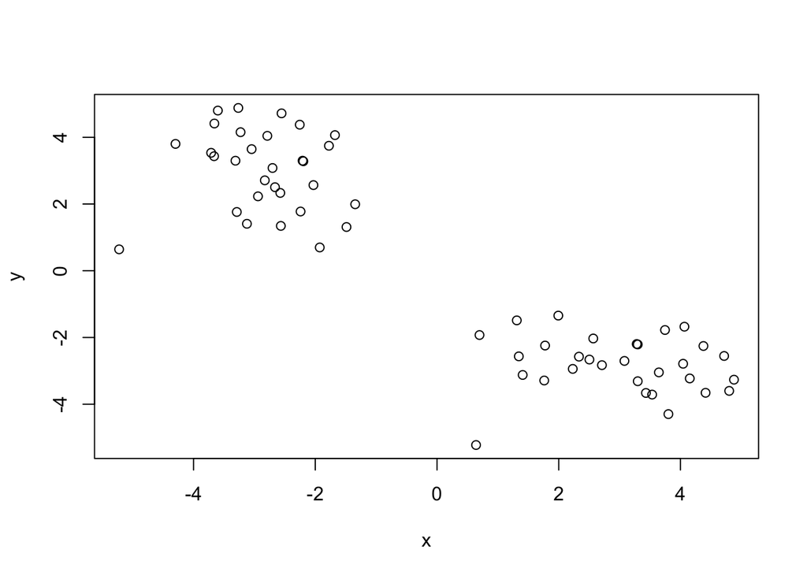

```r
# Generate some example data for clustering
tmp <- c(rnorm(30,-3), rnorm(30,3))
# 30 random numbers with mean of -3, another 30 random numbers with mean of 3
x <- cbind(x=tmp, y=rev(tmp))
# bind the two vectors, but the "rev" version will be reversed
plot(x)
```

*Instructions:*

Use the kmeans() function setting k to 2 and nstart=20 Inspect/print the results

> Q. How many points are in each cluster? Q. What ‘component’ of your result object details - cluster size? - cluster assignment/membership? - cluster center? Plot x colored by the kmeans cluster assignment and add cluster centers as blue points

```r
km <- kmeans( x, centers = 2, nstart = 20 )
km
```

```
## K-means clustering with 2 clusters of sizes 30, 30
##
## Cluster means:
##           x         y
## 1 -2.805915  2.994804
## 2  2.994804 -2.805915
##
## Clustering vector:
##  [1] 1 1 1 1 1 1 1 1 1 1 1 1 1 1 1 1 1 1 1 1 1 1 1 1 1 1 1 1 1 1 2 2 2 2 2
## [36] 2 2 2 2 2 2 2 2 2 2 2 2 2 2 2 2 2 2 2 2 2 2 2 2 2
##
## Within cluster sum of squares by cluster:
## [1] 65.28914 65.28914
##  (between_SS / total_SS =  88.5 %)
##
## Available components:
##
## [1] "cluster"      "centers"      "totss"        "withinss"
## [5] "tot.withinss" "betweenss"    "size"         "iter"
## [9] "ifault"
```

Can view available components, look at help page for kmeans() to determine

> Q. How many points are in each cluster?

```r
km$size
```

```
## [1] 30 30
```

There are 30 points in each cluster.

> Q. What ‘component’ of your result object details - cluster size? “size”: also the first line of the returned info

```r
km$size
```

```
## [1] 30 30
```

```
  - cluster assignment/membership?
  "cluster":A vector of integers (from 1:k) indicating the cluster to which each point is allocated.
```

```r
km$cluster
```

```
##  [1] 1 1 1 1 1 1 1 1 1 1 1 1 1 1 1 1 1 1 1 1 1 1 1 1 1 1 1 1 1 1 2 2 2 2 2
## [36] 2 2 2 2 2 2 2 2 2 2 2 2 2 2 2 2 2 2 2 2 2 2 2 2 2
```

```
  - cluster center?
  Shown above in the "Cluster means"
```

```r
km$centers
```

```
##           x         y
## 1 -2.805915  2.994804
## 2  2.994804 -2.805915
```

Generate a plot

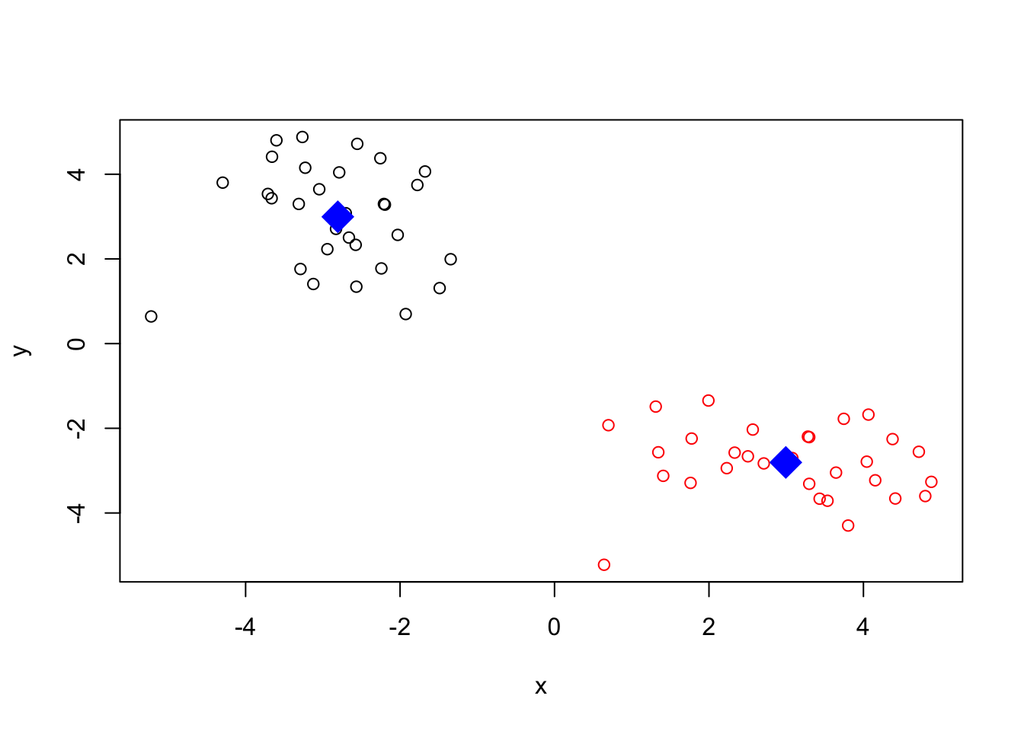

```r
plot(x, col=km$cluster)
points(km$centers, col = "blue", pch = 18, cex = 3)
```

## Hierarchical clustering

Main difference is that the number of clusters is not known ahead of time, so we don’t have to indicate a number of k clusters.

**The input to R must be a distance matrix of our data (x)**

```r
# First we need to calculate point (dis)similarity
#   as the Euclidean distance between observations
d <- dist_matrix <- dist(x)
# The hclust() function returns a hierarchical
#  clustering model
hc <- hclust(d = dist_matrix)
# the print method is not so useful here
hc
```

```
##
## Call:
## hclust(d = dist_matrix)
##
## Cluster method   : complete
## Distance         : euclidean
## Number of objects: 60
```

Not a lot of information given here. Let’s plot the results to get a better idea of the result.

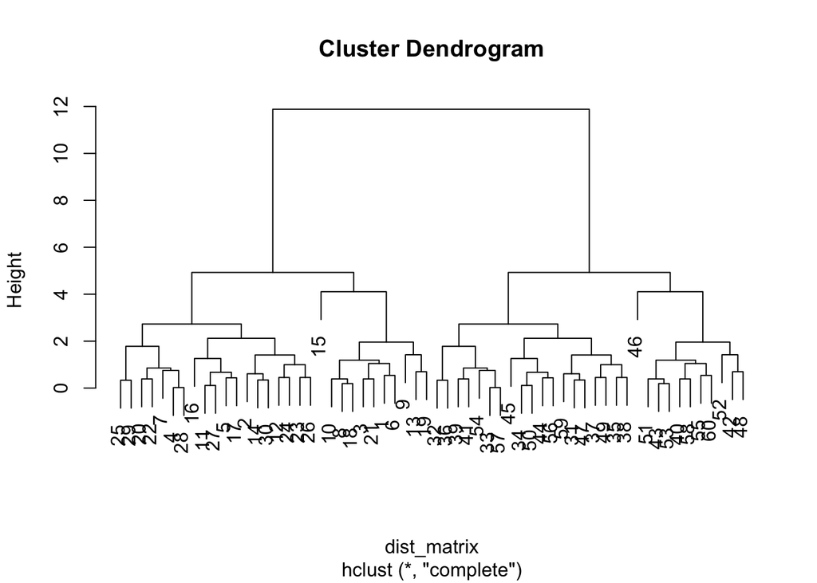

```r
plot(hc)
```

The result is a cluster dendrogram. There are 2 major groups (as expected based on our original data input).

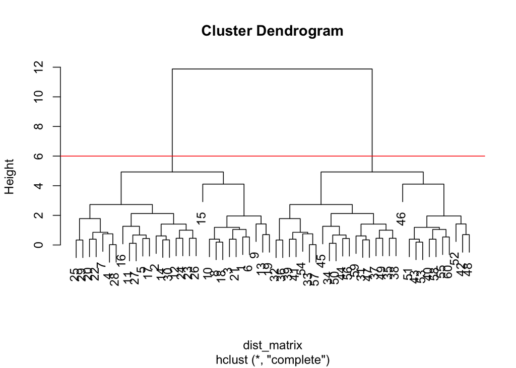

```r
plot(hc)
abline( h=6, col = "red")
```

```r
cutree(hc, h = 6)
```

```
##  [1] 1 1 1 1 1 1 1 1 1 1 1 1 1 1 1 1 1 1 1 1 1 1 1 1 1 1 1 1 1 1 2 2 2 2 2
## [36] 2 2 2 2 2 2 2 2 2 2 2 2 2 2 2 2 2 2 2 2 2 2 2 2 2
```

```r
gp2 <- cutree(hc, k = 2)
gp2
```

```
##  [1] 1 1 1 1 1 1 1 1 1 1 1 1 1 1 1 1 1 1 1 1 1 1 1 1 1 1 1 1 1 1 2 2 2 2 2
## [36] 2 2 2 2 2 2 2 2 2 2 2 2 2 2 2 2 2 2 2 2 2 2 2 2 2
```

```r
gp3<- cutree(hc, k =3)
gp3
```

```
##  [1] 1 1 1 1 1 1 1 1 1 1 1 1 1 1 1 1 1 1 1 1 1 1 1 1 1 1 1 1 1 1 2 2 2 2 2
## [36] 2 2 2 2 3 2 3 3 2 2 3 2 3 2 2 3 3 3 2 3 2 2 3 2 3
```

```r
table(gp2)
```

```
## gp2
##  1  2
## 30 30
```

```r
table(gp3)
```

```
## gp3
##  1  2  3
## 30 19 11
```

```r
table(gp2, gp3)
```

```
##    gp3
## gp2  1  2  3
##   1 30  0  0
##   2  0 19 11
```

There are 4 different methods to determine distance between clusters: complete (default), single, average, and centroid

Centroid is not used very often - gives weird looking trees